# Univariate tests

# Differential abundance testing for univariate data

This section covers basic univariate tests for two-group comparison, covering t-test, Wilcoxon test, and multiple testing.

The following example compares the abundance of a selected bug between two conditions. Let us assume that the data is already properly normalized.

Let us load exmaple data

```r
library(microbiome)
data(dietswap)
d <- dietswap

# Pick microbial abundances for a given taxonomic group
taxa <- "Dialister"

# Construct a data.frame with the selected
# taxonomic group and grouping
df <- data.frame(Abundance = abundances(d)[taxa,],
                 Group = meta(d)$nationality)
```

Compare the groups visually using a boxplot.

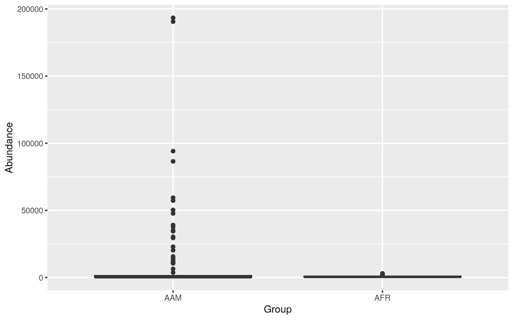

```r
p <- ggplot(df, aes(x = Group, y = Abundance)) +
       geom_boxplot()
print(p)
```

The abundances are in absolute scale and comparison is not clear. Therefore, let us use the log10 transformation. Now, the data contains many zeros and taking log10 will yield infinite values. Let us use the standard log10(1+x) transformation.

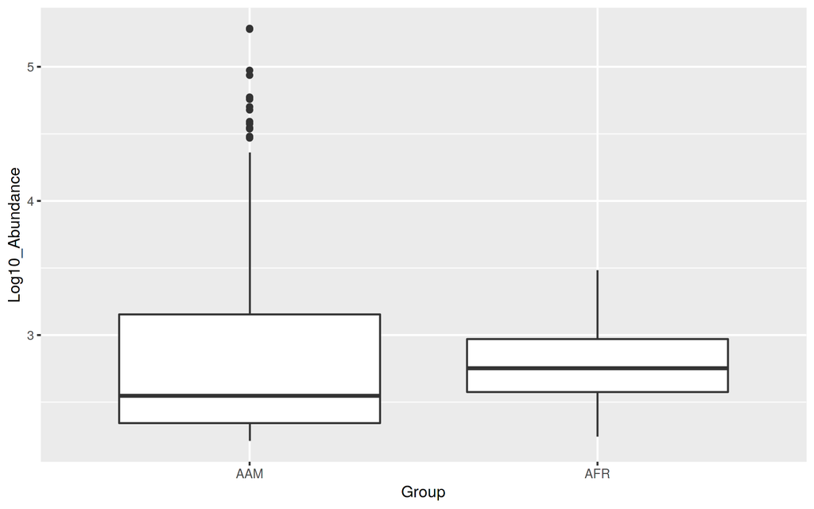

```r
df$Log10_Abundance <- log10(1 + df$Abundance)
p <- ggplot(df, aes(x = Group, y = Log10_Abundance)) +
       geom_boxplot()
print(p)
```

The groups seems to differ. Let us test the difference statistically. First, let us perform t-test, which is based on Gaussian assumptions. Each group is expected to follow Gaussian distribution.

Significance with t-test:

```r
print(t.test(Log10_Abundance ~ Group, data = df)$p.value)
```

```
## [1] 0.06032956
```

Now let us investigate the Gaussian assumption in more detail. Boxplots may not show deviations from Gaussian assumptions very clearly Let us try another visualization; the density plot.

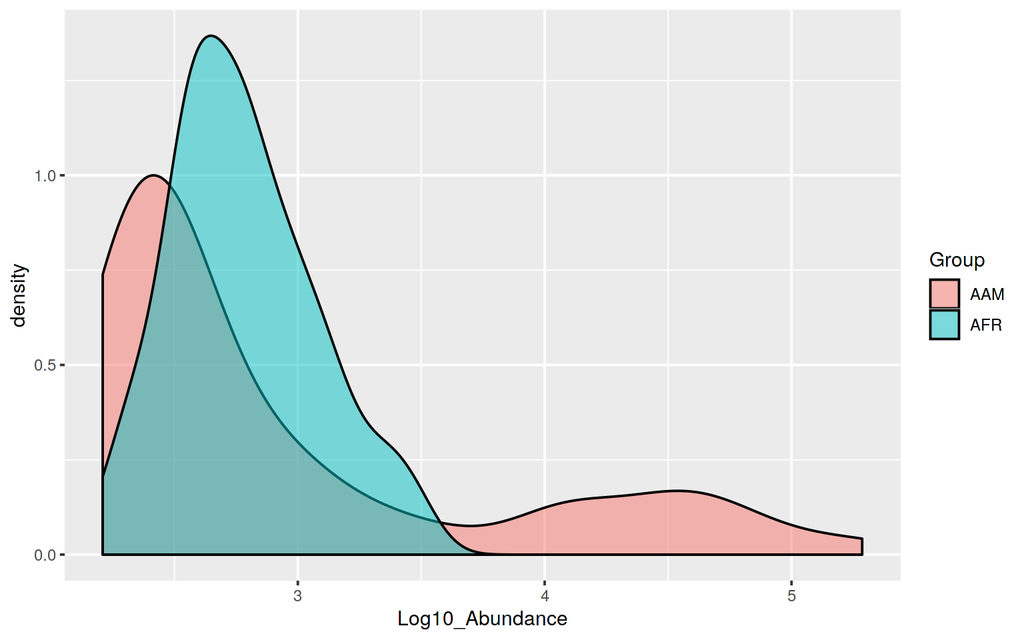

```r
p <- ggplot(df, aes(fill = Group, x = Log10_Abundance)) +
       geom_density(alpha = 0.5)
print(p)
```

The data is not Gaussian distributed. In such cases, a common procedure is to use non-parametric tests. These do not make assumptions of the data distribution but instead compare the ordering of the samples.